# Curvature measures from index constrained eigenvalue samples

Dennis Amelunxen

12 December, 2017

This note analyzes the curvature measures of symmetric cones (positive semdefinite real symmetric/complex unitary/quaternion unitary matrices) through the distribution of the Gaussian orthogonal/unitary/symplectic ensemble conditioned on the index function, that is, the number of positive eigenvalues. The approach follows closely the approach of reconstructing the conic intrinsic volumes from the corresponding bivariate chi-bar-squared distribution. We will assume familiarity with this approach, which is explained in the vignette Estimating conic intrinsic volumes from bivariate chi-bar-squared data from the `conivol` package. We present the connection between the curvature measures and the index constrained Gaussian orthogonal/unitary/symplectic ensemble without proof; for more information and references, see (Amelunxen and Bürgisser 2015).

**Vignettes from the `conivol` package:**

- Conic intrinsic volumes and (bivariate) chi-bar-squared distribution: introduces conic intrinsic volumes and (bivariate) chi-bar-squared distributions, as well as the computations involving polyhedral cones,
- Estimating conic intrinsic volumes from bivariate chi-bar-squared data: describes the details of the algorithm for finding the intrinsic volumes of closed convex cones from samples of the associated bivariate chi-bar-squared distribution,
- Bayesian estimates for conic intrinsic volumes: describes the Bayesian approach for reconstructing intrinsic volumes from sampling data, which can either be samples from the intrinsic volumes distribution (in the case of polyhedral cones), or from the bivariate chi-bar-squared distribution, and which can be with or without enforcing log-concavity of the intrinsic volumes.

## Symmetric cones

[Symmetric cones](https://en.wikipedia.org/wiki/Symmetric_cone) are self-dual convex cones with a transitive group of symmetries. Every symmetric cone decomposes into an orthogonal sum of a finite number of simple symmetric cones, which consist of

- the Lorentz cones (circular cones of radius $\pi/4$),
- positive semdefinite real symmetric matrices,
- positive semdefinite complex unitary matrices,
- positive semdefinite quaternion unitary matrices,
- positive semidefinite octionion unitary $3\times 3$-matrices.

The first four points each describe families of cones, while the last point is just one exceptional cone. The Lorentz cones have a very simple structure and do not have the kind of structure that we focus on in this note. We also do not discuss the exceptional symmertic cone. So “symmetric cone” in this note is synonymous to a cone of positive semidefinite real symmetric/complex unitary/quaternion unitary matrices of a certain format.

We use the Dyson index $\beta\in\{1,2,4\}$ to indicate whether the ground field is real ($\beta=1$), complex ($\beta=2$), or quaternion ($\beta=4$); we denote the size of the matrices by $n$. The set of real symmetric/complex unitary/quaternion unitary matrices form a Euclidean space $\mathcal{E}$ of dimension
$$d = n + \beta\binom{n}{2}
= \frac{\beta}{2} n^2 \cdot \begin{cases} (1+\frac{1}{n}) & \text{if } \beta=1
\\ 1 & \text{if } \beta=2
\\ (1-\frac{1}{2n}) & \text{if } \beta=4 .
\end{cases}$$
The Gaussian orthogonal/symmetric/unitary ensemble, which we denote by $\text{G}\beta\text{E}$, is the standard normal distribution in $\mathcal{E}$ (choosing some orthonormal basis in $\mathcal{E}$ the distribution can be found by taking iid standard normal random variables for the resulting coordinates). This distribution on $\mathcal{E}$ induces a distribution on the Weyl chamber
$$W_n = \{x\in\text{R}^n\mid x_1\leq x_2\leq\dots\leq x_n \} ,$$
through the function that maps a matrix $A\in\mathcal{E}$ to its vector of ordered eigenvalues $\text{eig}(A)$. We slightly abuse notation and also denote this induced distribution on $W_n$ by $\text{G}\beta\text{E}$ (from the context it is clear whether we are talking about matrices or eigenvalues; we will mostly be talking about the eigenvalues). The norm on $\mathcal{E}$ is given by the (Euclidean) norm on the eigenvalues, $\|A\|=\|\text{eig}(A)\|$.

We denote the cone of positive semidefinite matrices by $C\subset\mathcal{E}$. The rank decomposition of $\mathcal{E}$ induces a rank decomposition of $C$, which we denote by
$$C = \bigcup_{r=0}^n M_r .$$
While the rank function is important, we will focus in this note on the index function that counts the number of positive entries in a vector,
$$\text{ind}(x)=(\text{number of positive entries in }x) .$$
Instead of the rank we can also use the index function to describe the strata of $C$,
$$M_r = \{A\in C\mid \text{ind}(\text{eig}(A))=r \} .$$

## Curvature measures of symmetric cones

The intrinsic volumes of a convex cone, and also the curvature measures that we will analyze here, can be described through corresponding (bivariate) chi-bar-squared distributions. For this we denote the orthogonal projection on the cone $C$ by $\Pi_C\colon\mathcal{E}\to C$,
$$\Pi_C(A) = \text{argmin}\{ \|A-B\| \mid B\in C \} .$$
The eigenvalues of the projection on $C$ and on its polar cone $C^\circ=-C$ are given by
$$\text{eig}\big(\Pi_C(A)\big) = \big(\text{eig}(A)\big)_+ ,\quad
\text{eig}\big(\Pi_{C^\circ}(A)\big) = \big(\text{eig}(A)\big)_- ,$$
where in $(x)_+=:x_+$ all negative entries of $x$ are replaced by zero, and similarly in $(x)_-=:x_-$ all positive entries of $x$ are replaced by zero. To simplify the notation we will now focus on the eigenvalues of the matrices.

The bivariate chi-bar-squared distribution of $C$ is the distribution of the pair
$$\big(\|x_+\|^2,\|x_-\|^2\big) ,\quad x\sim \text{G}\beta\text{E} .$$
The connection to the intrinsic volumes $v_k:=v_k(C)$, $0\leq k\leq d$, is given by an alternative way to describe this distribution: Let the discrete random variable $Z\in\{0,\ldots,d\}$ be described by the probabilities
$$\text{Prob}(Z=k) = v_k ,$$
then $(X_+,X_-)$ defined by
$$X_+\sim \chi_Z^2,\quad X_-\sim \chi_{d-Z}^2 ,\quad X_+,X_- \text{ independent} ,$$
has the same distribution as $\big(\|x_+\|^2,\|x_-\|^2\big)$. This property, known as the generalized Steiner formula, provides a characterization of the intrinsic volumes.

The curvature measures $\Phi_{kr} := \Phi_k(C,M_r)$ allow for a similar characterization if the $\text{G}\beta\text{E}$ is conditioned on the index. More precisely, if $\emptyset\neq R\subseteq\{0,\ldots,n\}$, then the pair
$$\big(\|x_+\|^2,\|x_-\|^2\big) ,\quad
x\sim \text{G}\beta\text{E}\mid\text{ind}(x)\in R$$
has the same distribution as $(X_+,X_-)$,
$$X_+\sim \chi_Z^2,\quad X_-\sim \chi_{d-Z}^2 ,\quad X_+,X_- \text{ independent} ,$$
if the latent variable $Z$ has the probabilities
$$\text{Prob}(Z=k) =
\frac{\sum_{r\in R} \Phi_{kr}}{\sum_{\ell=0}^d \sum_{r\in R} \Phi_{\ell r}} .$$
Again, this property, a consequence of a localized form of the general Steiner formula, characterizes the curvature measures $\Phi_{kr}$. We will discuss the issue of the normalizations $\sum_{\ell=0}^d \sum_{r\in R} \Phi_{\ell r}$ below, but before doing this we explain some important inequalities giving the range of the indices $k,r$ such that $\Phi_{kr}$ is nonzero.

### Pataki bounds

The curvature measure $\Phi_{kr}$ is nonzero iff the indices $k,r$ satisfy the inequalities
$$\begin{align*}
r + \beta \binom{r}{2} & \leq k \leq r + \beta \binom{r}{2} + \beta r (n-r)
= d - \Big( n-r + \beta \binom{n-r}{2} \Big)
\\ \iff &
\begin{cases}
\frac{r^2}{2}(1+\frac{1}{r}) \leq k \leq d
- \frac{(n-r)^2}{2} (1+\frac{1}{n-r}) & \text{if } \beta=1
\\ r^2 \leq k \leq d-(n-r)^2
& \text{if } \beta=2
\\ 2r^2 (1-\frac{1}{2r}) \leq k \leq d
- 2(n-r)^2 (1-\frac{1}{2(n-r)}) & \text{if } \beta=4
\end{cases}
\end{align*}$$
Rewriting these inequalities in terms of $\frac{k}{d}$ yields
$$\begin{align*}
& \frac{r + \beta \binom{r}{2}}{d} \leq \frac{k}{d} \leq
1 - \frac{n-r + \beta \binom{n-r}{2}}{d}
\\ \iff &
\begin{cases}
\frac{1+\frac{1}{r}}{1+\frac{1}{n}}\big(\frac{r}{n}\big)^2 \leq \frac{k}{d} \leq 1
- \frac{1+\frac{1}{n-r}}{1+\frac{1}{n}} \big(1-\frac{r}{n}\big)^2 & \text{if } \beta=1
\\ \big(\frac{r}{n}\big)^2 \leq \frac{k}{d} \leq 1-\big(1-\frac{r}{n}\big)^2
& \text{if } \beta=2
\\ \frac{1-\frac{1}{2r}}{1-\frac{1}{2n}}\big(\frac{r}{n}\big)^2 \leq \frac{k}{d} \leq 1
- \frac{1-\frac{1}{2(n-r)}}{1-\frac{1}{2n}}\big(1-\frac{r}{n}\big)^2 & \text{if } \beta=4
\end{cases}
\end{align*}$$

Asymptotically, we obtain for $n\to\infty$ and $r_n,k_n$ such that $\frac{r_n}{n}\to\rho\in(0,1)$ and $\frac{k_n}{n}\to\kappa\in(0,1)$, the inequalities
$$\rho^2 \leq \kappa\leq 1-(1-\rho)^2 ,\quad \text{for } \beta=1,2,4 .$$
We illustrate these inequalities for $n=3,6,10$, $\beta=1,2,4$: (the asymptotic bounds are indicated by the dashed curves)

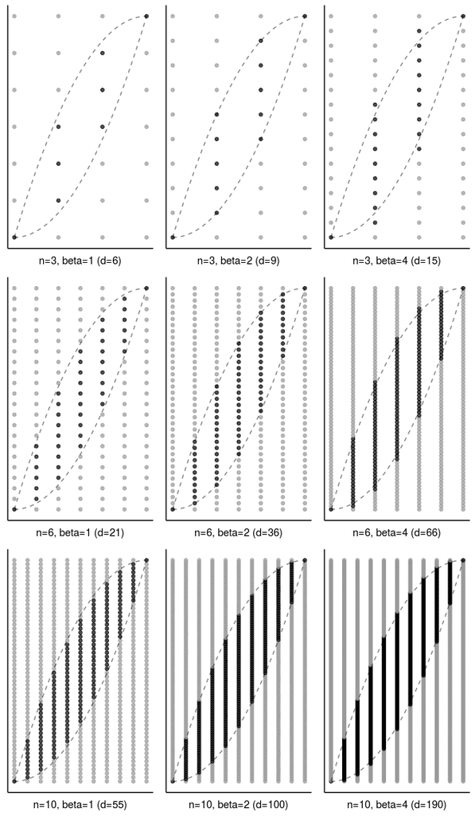

### Curvature measures normalized through index constraints

As explained above, by restricting the index to be equal to $r$, that is, $R=\{r\}$, we obtain the connection between the conditioned eigenvalue distribution $\text{G}\beta\text{E}\mid \text{ind}=r$ and the index normalized curvature measures
$$\Phi^{\text{ind}}_{kr} := \frac{\Phi_{kr}}{\sum_{\ell=0}^d \Phi_{\ell r}} ,\quad
k=0,\ldots,d .$$
Assuming that we have reconstructed these index normalized curvature measures as well as the intrinsic volumes $v_k$, we can reconstruct the unnormalized curvature measures: summing the curvature measures over $r$ yields the intrinsic volumes,
$$v_k = \sum_{r=0}^n \Phi_{kr} = \sum_{r=0}^n\Phi^{\text{ind}}_{kr} \sum_{\ell=0}^d \Phi_{\ell r} ;$$
solving this overdetermined linear system of equations gives
$$\bigg(\sum_{j=0}^d \Phi_{jr}\bigg) =
\big(\Phi^{\text{ind}}_{kr}\big)^\dagger\cdot\big(v_k\big) ,$$
where $.^\dagger$ denotes Moore-Penrose inversion, and thus
$$\big(\Phi_{kr}\big) = \big(\Phi^{\text{ind}}_{kr}\big)\cdot
\text{diag}\Big(\big(\Phi^{\text{ind}}_{kr}\big)^\dagger\cdot\big(v_k\big)\Big) .$$
The problem with this approach is that it is not pracical for even moderate sizes due to the double concentration in both $r$ and $k$ around $n/2$ and $d/2$, respectively, resulting in serious numerical issues.

But the unnormalized curvature measures are arguably not too interesting anyway, due to these concentration effects. Much more interesting are the curvature measures, which are normalized with respect to the other index; see (Amelunxen and Bürgisser 2015) for applications in semidefinite programming. We call these *dimension normalized* curvature measures,
$$\Phi^{\text{dim}}_{kr} := \frac{\Phi_{kr}}{\sum_{s=0}^n \Phi_{ks}} ,\quad
r=0,\ldots,n,\quad k=0,\ldots,d .$$
One might think of finding these from the index normalized curvature measures through the above described way of reconstructing the unnormalized curvature measures. But since this procedure is not numerically stable, we propose a different procedure as follows.

In addition to the index normalized curvature measures, which correspond to the choice $|\mathcal{R}|=1$, we assume to have reconstructed those corresponding to the choice $|\mathcal{R}|=2$. For notational convenience, fix $k\in\{0,\ldots,d\}$ and let us denote
$$\begin{align*}
a_r & := \Phi^{\text{ind}}_{kr} = \frac{\Phi_{kr}}{\sum_{j=0}^d \Phi_{jr}} ,
& r & =0,\ldots,n
\\ b_r & := \frac{\Phi_{kr}+\Phi_{k,r+1}}{\sum_{j=0}^d \big(\Phi_{jr}
+\Phi_{j,r+1}\big)} , & r & =0,\ldots,n-1
\\ c_r & := \frac{\Phi_{k,r+1}}{\Phi_{kr}} , & r & =0,\ldots,n-1 .
\end{align*}$$
Then we obtain
$$\begin{align*}
\frac{1}{b_r} & =
\frac{\sum_{j=0}^d \Phi_{jr}}{\Phi_{kr}}\frac{\Phi_{kr}}{\Phi_{kr}+\Phi_{k,r+1}}
+ \frac{\sum_{j=0}^d \Phi_{j,r+1}}{\Phi_{k,r+1}} \frac{\Phi_{k,r+1}}{\Phi_{kr}+\Phi_{k,r+1}}
\\ & = \frac{1}{a_r}\frac{1}{1+c_r} + \frac{1}{a_{r+1}}\frac{1}{\frac{1}{c_r}+1} .
\end{align*}$$

Solving this for $c_r$ yields
$$c_r = -\frac{\frac{1}{b_r}-\frac{1}{a_r}}{\frac{1}{b_r}-\frac{1}{a_{r+1}}}
= -\frac{a_{r+1}\big(a_r-b_r\big)}{a_r\big(a_{r+1}-b_r\big)} .$$
Using this formula to reconstruct $c_r$ it is now clear how to reconstruct the dimension normalized intrinsic volumes: for given dimension $k$,

1. find $r_0=\text{argmax}\{ \Phi^{\text{ind}}_{kr}\mid 0\leq r \leq n \}$  
   (this step is try to minimize numerical issues; in theory any index within the Pataki bounds would work)
2. set $\phi_{r_0}=1$ and define
   $$\begin{align*}
   \phi_{r_0+1} & := c_{r_0}, & \phi_{r_0+2} & := c_{r_0}c_{r_0+1},
   & \phi_{r_0+3} & := c_{r_0}c_{r_0+1}c_{r_0+2}, & \dots
   \\ \phi_{r_0-1} & := \frac{1}{c_{r_0-1}},
   & \phi_{r_0-2} & := \frac{1}{c_{r_0-1}c_{r_0-2}},
   & \phi_{r_0-3} & := \frac{1}{c_{r_0-1}c_{r_0-2}c_{r_0-3}}, & \dots
   \end{align*}$$
   (stay within the Pataki bounds, of course)
3. the dimension normalized curvature measures are then given by
   $$\Phi^{\text{dim}}_{kr} = \frac{\phi_r}{\sum_{s=0}^n \phi_s} ,\quad r=0,\ldots,n .$$

## Implementations

Having explained the general approach, it remains to implement the computations, which consist of two parts:

1. sampling from the index constrained eigenvalue distribution,
2. reconstructing the index normalized curvature measures from sampling data.

The difficulty of the first step lies in the again in the concentration effects. A random vector from the $\text{G}\beta\text{E}$ will have its index close to $n/2$ with high probability, making a simple rejection sampler (sample from $\text{G}\beta\text{E}$ then reject if the index is not as needed) a practically infeasible approach. Instead we will use the Hamiltonian Monte-Carlo sampler [Stan](http://mc-stan.org/) for this task.

## References

Amelunxen, Dennis, and Peter Bürgisser. 2015. “Intrinsic Volumes of Symmetric Cones and Applications in Convex Programming.” *Math. Program.* 149 (1-2, Ser. A): 105–30. https://doi.org/10.1007/s10107-013-0740-2.